# Risk Factor Analysis

## Outcome Variable

**Outcome Variable:** ever_stunted

## Predictor Variables

**Intervention Variable:** mwtkg

**Adjustment Set:**

unadjusted

## Stratifying Variables

The analysis was stratified on these variable(s):

- agecat
- studyid
- country

## Data Summary

| agecat | studyid | country | mwtkg | ever_stunted | n_cell | n | outcome_variable |
| --- | --- | --- | --- | --- | --- | --- | --- |
| 0-24 months | ki0047075b-MAL-ED | BANGLADESH | >=58 kg | 0 | 28 | 254 | ever_stunted |
| 0-24 months | ki0047075b-MAL-ED | BANGLADESH | >=58 kg | 1 | 20 | 254 | ever_stunted |
| 0-24 months | ki0047075b-MAL-ED | BANGLADESH | <52 kg | 0 | 49 | 254 | ever_stunted |
| 0-24 months | ki0047075b-MAL-ED | BANGLADESH | <52 kg | 1 | 113 | 254 | ever_stunted |
| 0-24 months | ki0047075b-MAL-ED | BANGLADESH | [52-58) kg | 0 | 21 | 254 | ever_stunted |
| 0-24 months | ki0047075b-MAL-ED | BANGLADESH | [52-58) kg | 1 | 23 | 254 | ever_stunted |
| 0-24 months | ki0047075b-MAL-ED | BRAZIL | >=58 kg | 0 | 106 | 221 | ever_stunted |
| 0-24 months | ki0047075b-MAL-ED | BRAZIL | >=58 kg | 1 | 37 | 221 | ever_stunted |
| 0-24 months | ki0047075b-MAL-ED | BRAZIL | <52 kg | 0 | 30 | 221 | ever_stunted |
| 0-24 months | ki0047075b-MAL-ED | BRAZIL | <52 kg | 1 | 12 | 221 | ever_stunted |
| 0-24 months | ki0047075b-MAL-ED | BRAZIL | [52-58) kg | 0 | 28 | 221 | ever_stunted |
| 0-24 months | ki0047075b-MAL-ED | BRAZIL | [52-58) kg | 1 | 8 | 221 | ever_stunted |
| 0-24 months | ki0047075b-MAL-ED | INDIA | >=58 kg | 0 | 22 | 242 | ever_stunted |
| 0-24 months | ki0047075b-MAL-ED | INDIA | >=58 kg | 1 | 20 | 242 | ever_stunted |
| 0-24 months | ki0047075b-MAL-ED | INDIA | <52 kg | 0 | 50 | 242 | ever_stunted |
| 0-24 months | ki0047075b-MAL-ED | INDIA | <52 kg | 1 | 100 | 242 | ever_stunted |
| 0-24 months | ki0047075b-MAL-ED | INDIA | [52-58) kg | 0 | 21 | 242 | ever_stunted |
| 0-24 months | ki0047075b-MAL-ED | INDIA | [52-58) kg | 1 | 29 | 242 | ever_stunted |
| 0-24 months | ki0047075b-MAL-ED | NEPAL | >=58 kg | 0 | 58 | 238 | ever_stunted |
| 0-24 months | ki0047075b-MAL-ED | NEPAL | >=58 kg | 1 | 22 | 238 | ever_stunted |
| 0-24 months | ki0047075b-MAL-ED | NEPAL | <52 kg | 0 | 37 | 238 | ever_stunted |
| 0-24 months | ki0047075b-MAL-ED | NEPAL | <52 kg | 1 | 39 | 238 | ever_stunted |
| 0-24 months | ki0047075b-MAL-ED | NEPAL | [52-58) kg | 0 | 60 | 238 | ever_stunted |
| 0-24 months | ki0047075b-MAL-ED | NEPAL | [52-58) kg | 1 | 22 | 238 | ever_stunted |
| 0-24 months | ki0047075b-MAL-ED | PERU | >=58 kg | 0 | 42 | 290 | ever_stunted |
| 0-24 months | ki0047075b-MAL-ED | PERU | >=58 kg | 1 | 62 | 290 | ever_stunted |
| 0-24 months | ki0047075b-MAL-ED | PERU | <52 kg | 0 | 42 | 290 | ever_stunted |
| 0-24 months | ki0047075b-MAL-ED | PERU | <52 kg | 1 | 73 | 290 | ever_stunted |
| 0-24 months | ki0047075b-MAL-ED | PERU | [52-58) kg | 0 | 20 | 290 | ever_stunted |
| 0-24 months | ki0047075b-MAL-ED | PERU | [52-58) kg | 1 | 51 | 290 | ever_stunted |

[output cut: 270 more lines]

The following strata were considered:

- agecat: 0-24 months, studyid: ki0047075b-MAL-ED, country: BANGLADESH
- agecat: 0-24 months, studyid: ki0047075b-MAL-ED, country: BRAZIL
- agecat: 0-24 months, studyid: ki0047075b-MAL-ED, country: INDIA
- agecat: 0-24 months, studyid: ki0047075b-MAL-ED, country: NEPAL
- agecat: 0-24 months, studyid: ki0047075b-MAL-ED, country: PERU
- agecat: 0-24 months, studyid: ki0047075b-MAL-ED, country: SOUTH AFRICA
- agecat: 0-24 months, studyid: ki0047075b-MAL-ED, country: TANZANIA, UNITED REPUBLIC OF
- agecat: 0-24 months, studyid: ki1000304b-SAS-CompFeed, country: INDIA
- agecat: 0-24 months, studyid: ki1017093-NIH-Birth, country: BANGLADESH
- agecat: 0-24 months, studyid: ki1017093b-PROVIDE, country: BANGLADESH
- agecat: 0-24 months, studyid: ki1017093c-NIH-Crypto, country: BANGLADESH
- agecat: 0-24 months, studyid: ki1066203-TanzaniaChild2, country: TANZANIA, UNITED REPUBLIC OF
- agecat: 0-24 months, studyid: ki1112895-iLiNS-Zinc, country: BURKINA FASO
- agecat: 0-24 months, studyid: ki1119695-PROBIT, country: BELARUS
- agecat: 0-24 months, studyid: ki1126311-ZVITAMBO, country: ZIMBABWE
- agecat: 0-24 months, studyid: ki1148112-LCNI-5, country: MALAWI
- agecat: 0-24 months, studyid: kiGH5241-JiVitA-3, country: BANGLADESH
- agecat: 0-6 months, studyid: ki0047075b-MAL-ED, country: BANGLADESH
- agecat: 0-6 months, studyid: ki0047075b-MAL-ED, country: BRAZIL
- agecat: 0-6 months, studyid: ki0047075b-MAL-ED, country: INDIA
- agecat: 0-6 months, studyid: ki0047075b-MAL-ED, country: NEPAL
- agecat: 0-6 months, studyid: ki0047075b-MAL-ED, country: PERU
- agecat: 0-6 months, studyid: ki0047075b-MAL-ED, country: SOUTH AFRICA
- agecat: 0-6 months, studyid: ki0047075b-MAL-ED, country: TANZANIA, UNITED REPUBLIC OF
- agecat: 0-6 months, studyid: ki1000304b-SAS-CompFeed, country: INDIA
- agecat: 0-6 months, studyid: ki1017093-NIH-Birth, country: BANGLADESH
- agecat: 0-6 months, studyid: ki1017093b-PROVIDE, country: BANGLADESH
- agecat: 0-6 months, studyid: ki1017093c-NIH-Crypto, country: BANGLADESH
- agecat: 0-6 months, studyid: ki1066203-TanzaniaChild2, country: TANZANIA, UNITED REPUBLIC OF
- agecat: 0-6 months, studyid: ki1119695-PROBIT, country: BELARUS
- agecat: 0-6 months, studyid: ki1126311-ZVITAMBO, country: ZIMBABWE
- agecat: 0-6 months, studyid: ki1148112-LCNI-5, country: MALAWI
- agecat: 0-6 months, studyid: kiGH5241-JiVitA-3, country: BANGLADESH
- agecat: 6-24 months, studyid: ki0047075b-MAL-ED, country: BANGLADESH
- agecat: 6-24 months, studyid: ki0047075b-MAL-ED, country: BRAZIL
- agecat: 6-24 months, studyid: ki0047075b-MAL-ED, country: INDIA
- agecat: 6-24 months, studyid: ki0047075b-MAL-ED, country: NEPAL
- agecat: 6-24 months, studyid: ki0047075b-MAL-ED, country: PERU
- agecat: 6-24 months, studyid: ki0047075b-MAL-ED, country: SOUTH AFRICA
- agecat: 6-24 months, studyid: ki0047075b-MAL-ED, country: TANZANIA, UNITED REPUBLIC OF
- agecat: 6-24 months, studyid: ki1000304b-SAS-CompFeed, country: INDIA
- agecat: 6-24 months, studyid: ki1017093-NIH-Birth, country: BANGLADESH
- agecat: 6-24 months, studyid: ki1017093b-PROVIDE, country: BANGLADESH
- agecat: 6-24 months, studyid: ki1017093c-NIH-Crypto, country: BANGLADESH
- agecat: 6-24 months, studyid: ki1066203-TanzaniaChild2, country: TANZANIA, UNITED REPUBLIC OF
- agecat: 6-24 months, studyid: ki1112895-iLiNS-Zinc, country: BURKINA FASO
- agecat: 6-24 months, studyid: ki1119695-PROBIT, country: BELARUS
- agecat: 6-24 months, studyid: ki1126311-ZVITAMBO, country: ZIMBABWE
- agecat: 6-24 months, studyid: ki1148112-LCNI-5, country: MALAWI
- agecat: 6-24 months, studyid: kiGH5241-JiVitA-3, country: BANGLADESH

### Dropped Strata

Some strata were dropped due to rare outcomes:

- agecat: 6-24 months, studyid: ki0047075b-MAL-ED, country: BRAZIL

## Methods Detail

We’re interested in the causal parameters $E[Y_a]$ for all values of $a \in \mathcal{A}$. These parameters represent the mean outcome if, possibly contrary to fact, we intervened to set all units to have $A=a$. Under the randomization and positivity assumptions, these are identified by the statistical parameters $\psi_a=E_W[E_{Y|A,W}(Y|A=a,W)]$. In addition, we’re interested in the mean of $Y$, $E[Y]$ under no intervention (the observed mean). We will estimate these parameters by using SuperLearner to fit the relevant likelihood factors – $E_{Y|A,W}(Y|A=a,W)$ and $p(A=a|W)$, and then updating our likelihood fit using a joint TMLE.

For unadjusted analyses ($W=\{\}$), initial likelihoods were estimated using Lrnr_glm to estimate the simple $E(Y|A)$ and Lrnr_mean to estimate $p(A)$. For adjusted analyses, a small library containing Lrnr_glmnet, Lrnr_xgboost, and Lrnr_mean was used.

Having estimated these parameters, we will then use the delta method to estimate relative risks and attributable risks relative to a prespecified baseline level of $A$.

# Results Detail

## Results Plots

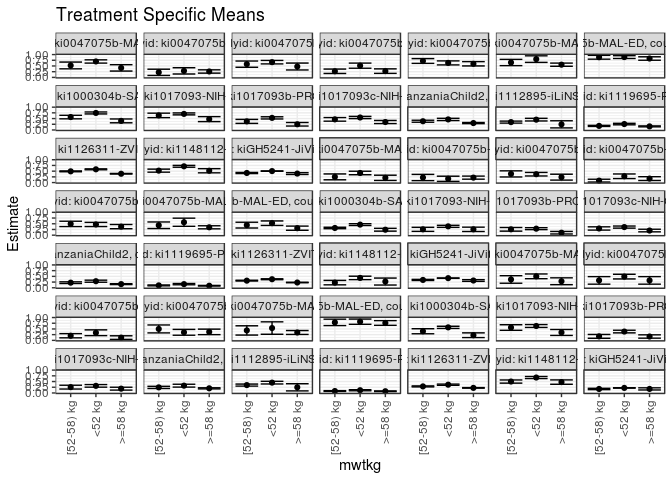

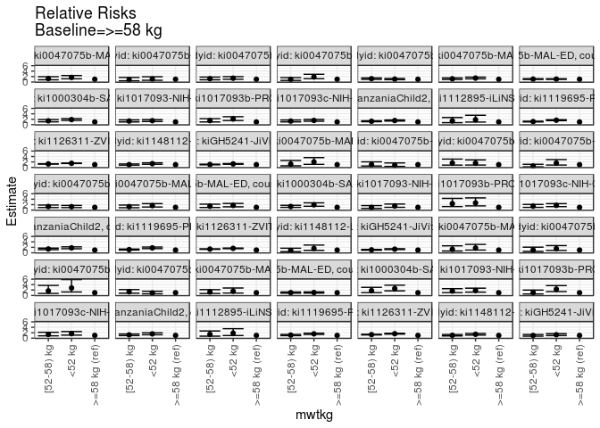

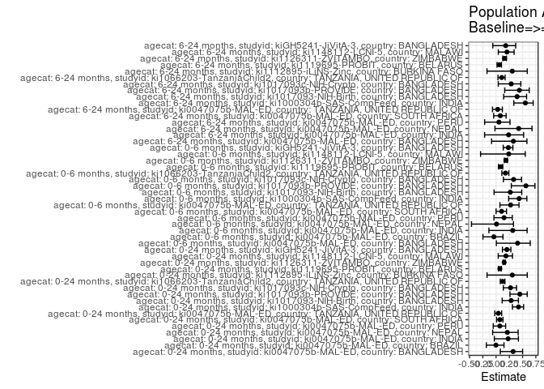

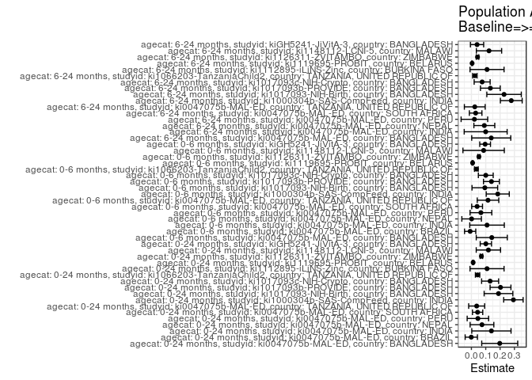

## Results Table

### Parameter: TSM

| agecat | studyid | country | intervention_level | baseline_level | estimate | ci_lower | ci_upper |
| --- | --- | --- | --- | --- | --- | --- | --- |
| 0-24 months | ki0047075b-MAL-ED | BANGLADESH | >=58 kg | NA | 0.4166667 | 0.2769215 | 0.5564118 |
| 0-24 months | ki0047075b-MAL-ED | BANGLADESH | <52 kg | NA | 0.6975309 | 0.6266597 | 0.7684020 |
| 0-24 months | ki0047075b-MAL-ED | BANGLADESH | [52-58) kg | NA | 0.5227273 | 0.3748507 | 0.6706038 |
| 0-24 months | ki0047075b-MAL-ED | BRAZIL | >=58 kg | NA | 0.2587413 | 0.1867992 | 0.3306833 |
| 0-24 months | ki0047075b-MAL-ED | BRAZIL | <52 kg | NA | 0.2857143 | 0.1487806 | 0.4226479 |
| 0-24 months | ki0047075b-MAL-ED | BRAZIL | [52-58) kg | NA | 0.2222222 | 0.0861081 | 0.3583363 |
| 0-24 months | ki0047075b-MAL-ED | INDIA | >=58 kg | NA | 0.4761905 | 0.3248345 | 0.6275465 |
| 0-24 months | ki0047075b-MAL-ED | INDIA | <52 kg | NA | 0.6666667 | 0.5910713 | 0.7422621 |
| 0-24 months | ki0047075b-MAL-ED | INDIA | [52-58) kg | NA | 0.5800000 | 0.4429115 | 0.7170885 |
| 0-24 months | ki0047075b-MAL-ED | NEPAL | >=58 kg | NA | 0.2750000 | 0.1769488 | 0.3730512 |
| 0-24 months | ki0047075b-MAL-ED | NEPAL | <52 kg | NA | 0.5131579 | 0.4005484 | 0.6257674 |
| 0-24 months | ki0047075b-MAL-ED | NEPAL | [52-58) kg | NA | 0.2682927 | 0.1721915 | 0.3643938 |
| 0-24 months | ki0047075b-MAL-ED | PERU | >=58 kg | NA | 0.5961538 | 0.5016893 | 0.6906184 |
| 0-24 months | ki0047075b-MAL-ED | PERU | <52 kg | NA | 0.6347826 | 0.5466295 | 0.7229357 |
| 0-24 months | ki0047075b-MAL-ED | PERU | [52-58) kg | NA | 0.7183099 | 0.6134979 | 0.8231218 |
| 0-24 months | ki0047075b-MAL-ED | SOUTH AFRICA | >=58 kg | NA | 0.5567010 | 0.4866665 | 0.6267356 |
| 0-24 months | ki0047075b-MAL-ED | SOUTH AFRICA | <52 kg | NA | 0.8000000 | 0.6565987 | 0.9434013 |
| 0-24 months | ki0047075b-MAL-ED | SOUTH AFRICA | [52-58) kg | NA | 0.6521739 | 0.5142823 | 0.7900655 |
| 0-24 months | ki0047075b-MAL-ED | TANZANIA, UNITED REPUBLIC OF | >=58 kg | NA | 0.8265306 | 0.7514158 | 0.9016455 |
| 0-24 months | ki0047075b-MAL-ED | TANZANIA, UNITED REPUBLIC OF | <52 kg | NA | 0.8888889 | 0.8268616 | 0.9509162 |
| 0-24 months | ki0047075b-MAL-ED | TANZANIA, UNITED REPUBLIC OF | [52-58) kg | NA | 0.8813559 | 0.7986816 | 0.9640303 |
| 0-24 months | ki1000304b-SAS-CompFeed | INDIA | >=58 kg | NA | 0.3982301 | 0.3142274 | 0.4822328 |
| 0-24 months | ki1000304b-SAS-CompFeed | INDIA | <52 kg | NA | 0.7456897 | 0.7032384 | 0.7881410 |
| 0-24 months | ki1000304b-SAS-CompFeed | INDIA | [52-58) kg | NA | 0.5661157 | 0.4893286 | 0.6429028 |
| 0-24 months | ki1017093-NIH-Birth | BANGLADESH | >=58 kg | NA | 0.4756098 | 0.3674317 | 0.5837879 |
| 0-24 months | ki1017093-NIH-Birth | BANGLADESH | <52 kg | NA | 0.7041943 | 0.6621319 | 0.7462567 |
| 0-24 months | ki1017093-NIH-Birth | BANGLADESH | [52-58) kg | NA | 0.6382979 | 0.5410865 | 0.7355092 |
| 0-24 months | ki1017093b-PROVIDE | BANGLADESH | >=58 kg | NA | 0.2500000 | 0.1724677 | 0.3275323 |
| 0-24 months | ki1017093b-PROVIDE | BANGLADESH | <52 kg | NA | 0.5300926 | 0.4829934 | 0.5771917 |
| 0-24 months | ki1017093b-PROVIDE | BANGLADESH | [52-58) kg | NA | 0.3760684 | 0.2882305 | 0.4639063 |

[output cut: 117 more lines]

### Parameter: E(Y)

| agecat | studyid | country | intervention_level | baseline_level | estimate | ci_lower | ci_upper |
| --- | --- | --- | --- | --- | --- | --- | --- |
| 0-24 months | ki0047075b-MAL-ED | BANGLADESH | NA | NA | 0.6141732 | 0.5541901 | 0.6741564 |
| 0-24 months | ki0047075b-MAL-ED | BRAZIL | NA | NA | 0.2579186 | 0.2001084 | 0.3157287 |
| 0-24 months | ki0047075b-MAL-ED | INDIA | NA | NA | 0.6157025 | 0.5542897 | 0.6771153 |
| 0-24 months | ki0047075b-MAL-ED | NEPAL | NA | NA | 0.3487395 | 0.2880656 | 0.4094134 |
| 0-24 months | ki0047075b-MAL-ED | PERU | NA | NA | 0.6413793 | 0.5860858 | 0.6966728 |
| 0-24 months | ki0047075b-MAL-ED | SOUTH AFRICA | NA | NA | 0.6000000 | 0.5414566 | 0.6585434 |
| 0-24 months | ki0047075b-MAL-ED | TANZANIA, UNITED REPUBLIC OF | NA | NA | 0.8632812 | 0.8211147 | 0.9054478 |
| 0-24 months | ki1000304b-SAS-CompFeed | INDIA | NA | NA | 0.6910891 | 0.6503148 | 0.7318634 |
| 0-24 months | ki1017093-NIH-Birth | BANGLADESH | NA | NA | 0.6645469 | 0.6276196 | 0.7014742 |
| 0-24 months | ki1017093b-PROVIDE | BANGLADESH | NA | NA | 0.4529148 | 0.4151667 | 0.4906629 |
| 0-24 months | ki1017093c-NIH-Crypto | BANGLADESH | NA | NA | 0.4794702 | 0.4438115 | 0.5151289 |
| 0-24 months | ki1066203-TanzaniaChild2 | TANZANIA, UNITED REPUBLIC OF | NA | NA | 0.3465136 | 0.3272783 | 0.3657490 |
| 0-24 months | ki1112895-iLiNS-Zinc | BURKINA FASO | NA | NA | 0.3566542 | 0.3069876 | 0.4063208 |
| 0-24 months | ki1119695-PROBIT | BELARUS | NA | NA | 0.1694743 | 0.1504830 | 0.1884655 |
| 0-24 months | ki1126311-ZVITAMBO | ZIMBABWE | NA | NA | 0.4563549 | 0.4471315 | 0.4655783 |
| 0-24 months | ki1148112-LCNI-5 | MALAWI | NA | NA | 0.6360382 | 0.6034429 | 0.6686335 |
| 0-24 months | kiGH5241-JiVitA-3 | BANGLADESH | NA | NA | 0.4953670 | 0.4875503 | 0.5031837 |
| 0-6 months | ki0047075b-MAL-ED | BANGLADESH | NA | NA | 0.3503937 | 0.2916054 | 0.4091820 |
| 0-6 months | ki0047075b-MAL-ED | BRAZIL | NA | NA | 0.2081448 | 0.1544982 | 0.2617914 |
| 0-6 months | ki0047075b-MAL-ED | INDIA | NA | NA | 0.3471074 | 0.2870050 | 0.4072099 |
| 0-6 months | ki0047075b-MAL-ED | NEPAL | NA | NA | 0.1764706 | 0.1279362 | 0.2250050 |
| 0-6 months | ki0047075b-MAL-ED | PERU | NA | NA | 0.4413793 | 0.3841309 | 0.4986278 |
| 0-6 months | ki0047075b-MAL-ED | SOUTH AFRICA | NA | NA | 0.3851852 | 0.3270313 | 0.4433391 |
| 0-6 months | ki0047075b-MAL-ED | TANZANIA, UNITED REPUBLIC OF | NA | NA | 0.4218750 | 0.3612599 | 0.4824901 |
| 0-6 months | ki1000304b-SAS-CompFeed | INDIA | NA | NA | 0.4226190 | 0.3935114 | 0.4517267 |
| 0-6 months | ki1017093-NIH-Birth | BANGLADESH | NA | NA | 0.3497615 | 0.3124631 | 0.3870600 |
| 0-6 months | ki1017093b-PROVIDE | BANGLADESH | NA | NA | 0.2481315 | 0.2153770 | 0.2808861 |
| 0-6 months | ki1017093c-NIH-Crypto | BANGLADESH | NA | NA | 0.3033113 | 0.2704998 | 0.3361228 |
| 0-6 months | ki1066203-TanzaniaChild2 | TANZANIA, UNITED REPUBLIC OF | NA | NA | 0.1943027 | 0.1783091 | 0.2102964 |
| 0-6 months | ki1119695-PROBIT | BELARUS | NA | NA | 0.0970084 | 0.0840167 | 0.1100001 |
| 0-6 months | ki1126311-ZVITAMBO | ZIMBABWE | NA | NA | 0.2824844 | 0.2741425 | 0.2908263 |
| 0-6 months | ki1148112-LCNI-5 | MALAWI | NA | NA | 0.3579336 | 0.3007518 | 0.4151153 |
| 0-6 months | kiGH5241-JiVitA-3 | BANGLADESH | NA | NA | 0.4129746 | 0.4055418 | 0.4204074 |
| 6-24 months | ki0047075b-MAL-ED | BANGLADESH | NA | NA | 0.4240506 | 0.3467471 | 0.5013542 |
| 6-24 months | ki0047075b-MAL-ED | INDIA | NA | NA | 0.4220779 | 0.3438191 | 0.5003367 |
| 6-24 months | ki0047075b-MAL-ED | NEPAL | NA | NA | 0.2113402 | 0.1537425 | 0.2689379 |
| 6-24 months | ki0047075b-MAL-ED | PERU | NA | NA | 0.3918919 | 0.3129763 | 0.4708075 |
| 6-24 months | ki0047075b-MAL-ED | SOUTH AFRICA | NA | NA | 0.3741935 | 0.2977649 | 0.4506221 |
| 6-24 months | ki0047075b-MAL-ED | TANZANIA, UNITED REPUBLIC OF | NA | NA | 0.7847222 | 0.7173567 | 0.8520877 |
| 6-24 months | ki1000304b-SAS-CompFeed | INDIA | NA | NA | 0.5030826 | 0.4587775 | 0.5473878 |
| 6-24 months | ki1017093-NIH-Birth | BANGLADESH | NA | NA | 0.5739130 | 0.5216565 | 0.6261696 |
| 6-24 months | ki1017093b-PROVIDE | BANGLADESH | NA | NA | 0.3004386 | 0.2583143 | 0.3425629 |
| 6-24 months | ki1017093c-NIH-Crypto | BANGLADESH | NA | NA | 0.2628458 | 0.2244546 | 0.3012371 |
| 6-24 months | ki1066203-TanzaniaChild2 | TANZANIA, UNITED REPUBLIC OF | NA | NA | 0.2277354 | 0.2069978 | 0.2484730 |
| 6-24 months | ki1112895-iLiNS-Zinc | BURKINA FASO | NA | NA | 0.3566542 | 0.3069876 | 0.4063208 |
| 6-24 months | ki1119695-PROBIT | BELARUS | NA | NA | 0.0803025 | 0.0658938 | 0.0947113 |
| 6-24 months | ki1126311-ZVITAMBO | ZIMBABWE | NA | NA | 0.2645703 | 0.2545045 | 0.2746362 |
| 6-24 months | ki1148112-LCNI-5 | MALAWI | NA | NA | 0.5989011 | 0.5632737 | 0.6345285 |
| 6-24 months | kiGH5241-JiVitA-3 | BANGLADESH | NA | NA | 0.2162884 | 0.2069101 | 0.2256667 |

### Parameter: RR

| agecat | studyid | country | intervention_level | baseline_level | estimate | ci_lower | ci_upper |
| --- | --- | --- | --- | --- | --- | --- | --- |
| 0-24 months | ki0047075b-MAL-ED | BANGLADESH | >=58 kg | >=58 kg | 1.0000000 | 1.0000000 | 1.000000 |
| 0-24 months | ki0047075b-MAL-ED | BANGLADESH | <52 kg | >=58 kg | 1.6740741 | 1.1791805 | 2.376671 |
| 0-24 months | ki0047075b-MAL-ED | BANGLADESH | [52-58) kg | >=58 kg | 1.2545455 | 0.8089716 | 1.945537 |
| 0-24 months | ki0047075b-MAL-ED | BRAZIL | >=58 kg | >=58 kg | 1.0000000 | 1.0000000 | 1.000000 |
| 0-24 months | ki0047075b-MAL-ED | BRAZIL | <52 kg | >=58 kg | 1.1042471 | 0.6344996 | 1.921769 |
| 0-24 months | ki0047075b-MAL-ED | BRAZIL | [52-58) kg | >=58 kg | 0.8588589 | 0.4383144 | 1.682898 |
| 0-24 months | ki0047075b-MAL-ED | INDIA | >=58 kg | >=58 kg | 1.0000000 | 1.0000000 | 1.000000 |
| 0-24 months | ki0047075b-MAL-ED | INDIA | <52 kg | >=58 kg | 1.4000000 | 0.9990041 | 1.961954 |
| 0-24 months | ki0047075b-MAL-ED | INDIA | [52-58) kg | >=58 kg | 1.2180000 | 0.8196426 | 1.809964 |
| 0-24 months | ki0047075b-MAL-ED | NEPAL | >=58 kg | >=58 kg | 1.0000000 | 1.0000000 | 1.000000 |
| 0-24 months | ki0047075b-MAL-ED | NEPAL | <52 kg | >=58 kg | 1.8660287 | 1.2277016 | 2.836245 |
| 0-24 months | ki0047075b-MAL-ED | NEPAL | [52-58) kg | >=58 kg | 0.9756098 | 0.5885491 | 1.617222 |
| 0-24 months | ki0047075b-MAL-ED | PERU | >=58 kg | >=58 kg | 1.0000000 | 1.0000000 | 1.000000 |
| 0-24 months | ki0047075b-MAL-ED | PERU | <52 kg | >=58 kg | 1.0647966 | 0.8625050 | 1.314534 |
| 0-24 months | ki0047075b-MAL-ED | PERU | [52-58) kg | >=58 kg | 1.2049069 | 0.9714132 | 1.494524 |
| 0-24 months | ki0047075b-MAL-ED | SOUTH AFRICA | >=58 kg | >=58 kg | 1.0000000 | 1.0000000 | 1.000000 |
| 0-24 months | ki0047075b-MAL-ED | SOUTH AFRICA | <52 kg | >=58 kg | 1.4370370 | 1.1544123 | 1.788854 |
| 0-24 months | ki0047075b-MAL-ED | SOUTH AFRICA | [52-58) kg | >=58 kg | 1.1714976 | 0.9159929 | 1.498272 |
| 0-24 months | ki0047075b-MAL-ED | TANZANIA, UNITED REPUBLIC OF | >=58 kg | >=58 kg | 1.0000000 | 1.0000000 | 1.000000 |
| 0-24 months | ki0047075b-MAL-ED | TANZANIA, UNITED REPUBLIC OF | <52 kg | >=58 kg | 1.0754458 | 0.9590191 | 1.206007 |
| 0-24 months | ki0047075b-MAL-ED | TANZANIA, UNITED REPUBLIC OF | [52-58) kg | >=58 kg | 1.0663319 | 0.9357728 | 1.215107 |
| 0-24 months | ki1000304b-SAS-CompFeed | INDIA | >=58 kg | >=58 kg | 1.0000000 | 1.0000000 | 1.000000 |
| 0-24 months | ki1000304b-SAS-CompFeed | INDIA | <52 kg | >=58 kg | 1.8725096 | 1.5750316 | 2.226173 |
| 0-24 months | ki1000304b-SAS-CompFeed | INDIA | [52-58) kg | >=58 kg | 1.4215794 | 1.0619414 | 1.903013 |
| 0-24 months | ki1017093-NIH-Birth | BANGLADESH | >=58 kg | >=58 kg | 1.0000000 | 1.0000000 | 1.000000 |
| 0-24 months | ki1017093-NIH-Birth | BANGLADESH | <52 kg | >=58 kg | 1.4806136 | 1.1703384 | 1.873148 |
| 0-24 months | ki1017093-NIH-Birth | BANGLADESH | [52-58) kg | >=58 kg | 1.3420622 | 1.0206873 | 1.764626 |
| 0-24 months | ki1017093b-PROVIDE | BANGLADESH | >=58 kg | >=58 kg | 1.0000000 | 1.0000000 | 1.000000 |
| 0-24 months | ki1017093b-PROVIDE | BANGLADESH | <52 kg | >=58 kg | 2.1203704 | 1.5356975 | 2.927641 |
| 0-24 months | ki1017093b-PROVIDE | BANGLADESH | [52-58) kg | >=58 kg | 1.5042735 | 1.0202671 | 2.217889 |

[output cut: 117 more lines]

### Parameter: PAR

| agecat | studyid | country | intervention_level | baseline_level | estimate | ci_lower | ci_upper |
| --- | --- | --- | --- | --- | --- | --- | --- |
| 0-24 months | ki0047075b-MAL-ED | BANGLADESH | >=58 kg | NA | 0.1975066 | 0.0720244 | 0.3229887 |
| 0-24 months | ki0047075b-MAL-ED | BRAZIL | >=58 kg | NA | -0.0008227 | -0.0434813 | 0.0418359 |
| 0-24 months | ki0047075b-MAL-ED | INDIA | >=58 kg | NA | 0.1395120 | 0.0026602 | 0.2763638 |
| 0-24 months | ki0047075b-MAL-ED | NEPAL | >=58 kg | NA | 0.0737395 | -0.0089173 | 0.1563962 |
| 0-24 months | ki0047075b-MAL-ED | PERU | >=58 kg | NA | 0.0452255 | -0.0294778 | 0.1199288 |
| 0-24 months | ki0047075b-MAL-ED | SOUTH AFRICA | >=58 kg | NA | 0.0432990 | 0.0074698 | 0.0791281 |
| 0-24 months | ki0047075b-MAL-ED | TANZANIA, UNITED REPUBLIC OF | >=58 kg | NA | 0.0367506 | -0.0189308 | 0.0924320 |
| 0-24 months | ki1000304b-SAS-CompFeed | INDIA | >=58 kg | NA | 0.2928590 | 0.2251533 | 0.3605648 |
| 0-24 months | ki1017093-NIH-Birth | BANGLADESH | >=58 kg | NA | 0.1889371 | 0.0888626 | 0.2890117 |
| 0-24 months | ki1017093b-PROVIDE | BANGLADESH | >=58 kg | NA | 0.2029148 | 0.1302534 | 0.2755762 |
| 0-24 months | ki1017093c-NIH-Crypto | BANGLADESH | >=58 kg | NA | 0.1305119 | 0.0712826 | 0.1897411 |
| 0-24 months | ki1066203-TanzaniaChild2 | TANZANIA, UNITED REPUBLIC OF | >=58 kg | NA | 0.0429906 | 0.0278385 | 0.0581427 |
| 0-24 months | ki1112895-iLiNS-Zinc | BURKINA FASO | >=58 kg | NA | 0.1090555 | -0.0096082 | 0.2277192 |
| 0-24 months | ki1119695-PROBIT | BELARUS | >=58 kg | NA | 0.0121633 | 0.0078132 | 0.0165134 |
| 0-24 months | ki1126311-ZVITAMBO | ZIMBABWE | >=58 kg | NA | 0.0697384 | 0.0608861 | 0.0785907 |
| 0-24 months | ki1148112-LCNI-5 | MALAWI | >=58 kg | NA | 0.1184943 | 0.0336743 | 0.2033143 |
| 0-24 months | kiGH5241-JiVitA-3 | BANGLADESH | >=58 kg | NA | 0.1007481 | 0.0613209 | 0.1401754 |
| 0-6 months | ki0047075b-MAL-ED | BANGLADESH | >=58 kg | NA | 0.1420604 | 0.0338975 | 0.2502232 |
| 0-6 months | ki0047075b-MAL-ED | BRAZIL | >=58 kg | NA | -0.0086384 | -0.0477583 | 0.0304815 |
| 0-6 months | ki0047075b-MAL-ED | INDIA | >=58 kg | NA | 0.1090122 | -0.0113624 | 0.2293868 |
| 0-6 months | ki0047075b-MAL-ED | NEPAL | >=58 kg | NA | 0.0014706 | -0.0666265 | 0.0695677 |
| 0-6 months | ki0047075b-MAL-ED | PERU | >=58 kg | NA | 0.0663793 | -0.0093421 | 0.1421007 |
| 0-6 months | ki0047075b-MAL-ED | SOUTH AFRICA | >=58 kg | NA | 0.0398244 | 0.0021671 | 0.0774816 |
| 0-6 months | ki0047075b-MAL-ED | TANZANIA, UNITED REPUBLIC OF | >=58 kg | NA | 0.1157526 | 0.0406972 | 0.1908079 |
| 0-6 months | ki1000304b-SAS-CompFeed | INDIA | >=58 kg | NA | 0.1836810 | 0.1032399 | 0.2641220 |
| 0-6 months | ki1017093-NIH-Birth | BANGLADESH | >=58 kg | NA | 0.0936640 | 0.0042236 | 0.1831044 |
| 0-6 months | ki1017093b-PROVIDE | BANGLADESH | >=58 kg | NA | 0.1397982 | 0.0844920 | 0.1951044 |
| 0-6 months | ki1017093c-NIH-Crypto | BANGLADESH | >=58 kg | NA | 0.1001863 | 0.0485133 | 0.1518592 |
| 0-6 months | ki1066203-TanzaniaChild2 | TANZANIA, UNITED REPUBLIC OF | >=58 kg | NA | 0.0344111 | 0.0215047 | 0.0473175 |
| 0-6 months | ki1119695-PROBIT | BELARUS | >=58 kg | NA | 0.0083811 | 0.0045535 | 0.0122088 |
| 0-6 months | ki1126311-ZVITAMBO | ZIMBABWE | >=58 kg | NA | 0.0524004 | 0.0443665 | 0.0604344 |
| 0-6 months | ki1148112-LCNI-5 | MALAWI | >=58 kg | NA | 0.0852063 | -0.0590172 | 0.2294298 |
| 0-6 months | kiGH5241-JiVitA-3 | BANGLADESH | >=58 kg | NA | 0.0956093 | 0.0581766 | 0.1330420 |
| 6-24 months | ki0047075b-MAL-ED | BANGLADESH | >=58 kg | NA | 0.1383363 | 0.0022085 | 0.2744642 |
| 6-24 months | ki0047075b-MAL-ED | INDIA | >=58 kg | NA | 0.0994973 | -0.0501929 | 0.2491875 |
| 6-24 months | ki0047075b-MAL-ED | NEPAL | >=58 kg | NA | 0.0901281 | 0.0172641 | 0.1629921 |
| 6-24 months | ki0047075b-MAL-ED | PERU | >=58 kg | NA | 0.0209241 | -0.0717484 | 0.1135967 |
| 6-24 months | ki0047075b-MAL-ED | SOUTH AFRICA | >=58 kg | NA | 0.0296557 | -0.0140735 | 0.0733850 |
| 6-24 months | ki0047075b-MAL-ED | TANZANIA, UNITED REPUBLIC OF | >=58 kg | NA | 0.0235282 | -0.0490455 | 0.0961019 |
| 6-24 months | ki1000304b-SAS-CompFeed | INDIA | >=58 kg | NA | 0.2780826 | 0.2021053 | 0.3540599 |
| 6-24 months | ki1017093-NIH-Birth | BANGLADESH | >=58 kg | NA | 0.2277592 | 0.1075739 | 0.3479445 |
| 6-24 months | ki1017093b-PROVIDE | BANGLADESH | >=58 kg | NA | 0.1321218 | 0.0632255 | 0.2010180 |
| 6-24 months | ki1017093c-NIH-Crypto | BANGLADESH | >=58 kg | NA | 0.0749264 | 0.0192990 | 0.1305537 |
| 6-24 months | ki1066203-TanzaniaChild2 | TANZANIA, UNITED REPUBLIC OF | >=58 kg | NA | 0.0240850 | 0.0087303 | 0.0394398 |
| 6-24 months | ki1112895-iLiNS-Zinc | BURKINA FASO | >=58 kg | NA | 0.1090555 | -0.0096082 | 0.2277192 |
| 6-24 months | ki1119695-PROBIT | BELARUS | >=58 kg | NA | 0.0048832 | 0.0016642 | 0.0081023 |
| 6-24 months | ki1126311-ZVITAMBO | ZIMBABWE | >=58 kg | NA | 0.0427249 | 0.0336605 | 0.0517892 |
| 6-24 months | ki1148112-LCNI-5 | MALAWI | >=58 kg | NA | 0.1227106 | 0.0345548 | 0.2108665 |
| 6-24 months | kiGH5241-JiVitA-3 | BANGLADESH | >=58 kg | NA | 0.0394176 | -0.0068167 | 0.0856519 |

### Parameter: PAF

| agecat | studyid | country | intervention_level | baseline_level | estimate | ci_lower | ci_upper |
| --- | --- | --- | --- | --- | --- | --- | --- |
| 0-24 months | ki0047075b-MAL-ED | BANGLADESH | >=58 kg | NA | 0.3215812 | 0.0794041 | 0.5000498 |
| 0-24 months | ki0047075b-MAL-ED | BRAZIL | >=58 kg | NA | -0.0031898 | -0.1830006 | 0.1492905 |
| 0-24 months | ki0047075b-MAL-ED | INDIA | >=58 kg | NA | 0.2265900 | -0.0331690 | 0.4210404 |
| 0-24 months | ki0047075b-MAL-ED | NEPAL | >=58 kg | NA | 0.2114458 | -0.0644438 | 0.4158285 |
| 0-24 months | ki0047075b-MAL-ED | PERU | >=58 kg | NA | 0.0705128 | -0.0539896 | 0.1803084 |
| 0-24 months | ki0047075b-MAL-ED | SOUTH AFRICA | >=58 kg | NA | 0.0721649 | 0.0097011 | 0.1306889 |
| 0-24 months | ki0047075b-MAL-ED | TANZANIA, UNITED REPUBLIC OF | >=58 kg | NA | 0.0425709 | -0.0245477 | 0.1052924 |
| 0-24 months | ki1000304b-SAS-CompFeed | INDIA | >=58 kg | NA | 0.4237645 | 0.3090662 | 0.5194223 |
| 0-24 months | ki1017093-NIH-Birth | BANGLADESH | >=58 kg | NA | 0.2843097 | 0.1148337 | 0.4213374 |
| 0-24 months | ki1017093b-PROVIDE | BANGLADESH | >=58 kg | NA | 0.4480198 | 0.2623426 | 0.5869598 |
| 0-24 months | ki1017093c-NIH-Crypto | BANGLADESH | >=58 kg | NA | 0.2722002 | 0.1368983 | 0.3862918 |
| 0-24 months | ki1066203-TanzaniaChild2 | TANZANIA, UNITED REPUBLIC OF | >=58 kg | NA | 0.1240660 | 0.0792695 | 0.1666831 |
| 0-24 months | ki1112895-iLiNS-Zinc | BURKINA FASO | >=58 kg | NA | 0.3057738 | -0.1706669 | 0.5883116 |
| 0-24 months | ki1119695-PROBIT | BELARUS | >=58 kg | NA | 0.0717706 | 0.0435491 | 0.0991594 |
| 0-24 months | ki1126311-ZVITAMBO | ZIMBABWE | >=58 kg | NA | 0.1528162 | 0.1330886 | 0.1720948 |
| 0-24 months | ki1148112-LCNI-5 | MALAWI | >=58 kg | NA | 0.1863006 | 0.0406527 | 0.3098363 |
| 0-24 months | kiGH5241-JiVitA-3 | BANGLADESH | >=58 kg | NA | 0.2033808 | 0.1197259 | 0.2790857 |
| 0-6 months | ki0047075b-MAL-ED | BANGLADESH | >=58 kg | NA | 0.4054307 | 0.0052622 | 0.6446173 |
| 0-6 months | ki0047075b-MAL-ED | BRAZIL | >=58 kg | NA | -0.0415020 | -0.2473085 | 0.1303464 |
| 0-6 months | ki0047075b-MAL-ED | INDIA | >=58 kg | NA | 0.3140590 | -0.1353314 | 0.5855702 |
| 0-6 months | ki0047075b-MAL-ED | NEPAL | >=58 kg | NA | 0.0083333 | -0.4633876 | 0.3279957 |
| 0-6 months | ki0047075b-MAL-ED | PERU | >=58 kg | NA | 0.1503906 | -0.0401780 | 0.3060456 |
| 0-6 months | ki0047075b-MAL-ED | SOUTH AFRICA | >=58 kg | NA | 0.1033902 | -0.0000744 | 0.1961506 |
| 0-6 months | ki0047075b-MAL-ED | TANZANIA, UNITED REPUBLIC OF | >=58 kg | NA | 0.2743764 | 0.0724311 | 0.4323553 |
| 0-6 months | ki1000304b-SAS-CompFeed | INDIA | >=58 kg | NA | 0.4346255 | 0.2372201 | 0.5809428 |
| 0-6 months | ki1017093-NIH-Birth | BANGLADESH | >=58 kg | NA | 0.2677938 | -0.0377840 | 0.4833936 |
| 0-6 months | ki1017093b-PROVIDE | BANGLADESH | >=58 kg | NA | 0.5634036 | 0.2874283 | 0.7324951 |
| 0-6 months | ki1017093c-NIH-Crypto | BANGLADESH | >=58 kg | NA | 0.3303084 | 0.1383375 | 0.4795098 |
| 0-6 months | ki1066203-TanzaniaChild2 | TANZANIA, UNITED REPUBLIC OF | >=58 kg | NA | 0.1771006 | 0.1089749 | 0.2400175 |
| 0-6 months | ki1119695-PROBIT | BELARUS | >=58 kg | NA | 0.0863958 | 0.0451083 | 0.1258982 |
| 0-6 months | ki1126311-ZVITAMBO | ZIMBABWE | >=58 kg | NA | 0.1854985 | 0.1567523 | 0.2132646 |
| 0-6 months | ki1148112-LCNI-5 | MALAWI | >=58 kg | NA | 0.2380506 | -0.2925147 | 0.5508238 |
| 0-6 months | kiGH5241-JiVitA-3 | BANGLADESH | >=58 kg | NA | 0.2315138 | 0.1353894 | 0.3169514 |
| 6-24 months | ki0047075b-MAL-ED | BANGLADESH | >=58 kg | NA | 0.3262260 | -0.0849378 | 0.5815692 |
| 6-24 months | ki0047075b-MAL-ED | INDIA | >=58 kg | NA | 0.2357320 | -0.2160558 | 0.5196721 |
| 6-24 months | ki0047075b-MAL-ED | NEPAL | >=58 kg | NA | 0.4264597 | -0.0212821 | 0.6779064 |
| 6-24 months | ki0047075b-MAL-ED | PERU | >=58 kg | NA | 0.0533927 | -0.2153095 | 0.2626854 |
| 6-24 months | ki0047075b-MAL-ED | SOUTH AFRICA | >=58 kg | NA | 0.0792524 | -0.0454791 | 0.1891027 |
| 6-24 months | ki0047075b-MAL-ED | TANZANIA, UNITED REPUBLIC OF | >=58 kg | NA | 0.0299828 | -0.0672917 | 0.1183916 |
| 6-24 months | ki1000304b-SAS-CompFeed | INDIA | >=58 kg | NA | 0.5527574 | 0.3344713 | 0.6994480 |
| 6-24 months | ki1017093-NIH-Birth | BANGLADESH | >=58 kg | NA | 0.3968531 | 0.1437372 | 0.5751466 |
| 6-24 months | ki1017093b-PROVIDE | BANGLADESH | >=58 kg | NA | 0.4397630 | 0.1629070 | 0.6250530 |
| 6-24 months | ki1017093c-NIH-Crypto | BANGLADESH | >=58 kg | NA | 0.2850583 | 0.0414740 | 0.4667420 |
| 6-24 months | ki1066203-TanzaniaChild2 | TANZANIA, UNITED REPUBLIC OF | >=58 kg | NA | 0.1057589 | 0.0360797 | 0.1704011 |
| 6-24 months | ki1112895-iLiNS-Zinc | BURKINA FASO | >=58 kg | NA | 0.3057738 | -0.1706669 | 0.5883116 |
| 6-24 months | ki1119695-PROBIT | BELARUS | >=58 kg | NA | 0.0608107 | 0.0184189 | 0.1013716 |
| 6-24 months | ki1126311-ZVITAMBO | ZIMBABWE | >=58 kg | NA | 0.1614877 | 0.1267460 | 0.1948473 |
| 6-24 months | ki1148112-LCNI-5 | MALAWI | >=58 kg | NA | 0.2048930 | 0.0423577 | 0.3398420 |
| 6-24 months | kiGH5241-JiVitA-3 | BANGLADESH | >=58 kg | NA | 0.1822457 | -0.0615335 | 0.3700415 |